# 3D Model Analysis of Fate-tracked M. cavernosa colonies

Ian Combs – icombs2017@fau.edu

### All analyses performed with R version 4.0.1

# Basic setup of R environment

## Loading required packages

For the following analyses we will require the use of a number of different R packages. Most of which can be sourced from CRAN, but some must be downloaded from GitHub. We can use the following code to load in the packages and install any packages not previously installed in the R console.

```r
if (!require("pacman")) install.packages("pacman")
pacman::p_load("ggplot2", "FSA", "officer", "gridExtra", "ggpubr", "Rmisc", "rcompanion", "RColorBrewer", "vegan", "nparcomp", "RVAideMemoire", "pairwiseAdonis", "PMCMR", "PMCMRplus", "patchwork", "magrittr","reshape2", "stringr", "dplyr", "flextable")
pacman::p_load_gh("pmartinezarbizu/pairwiseAdonis/pairwiseAdonis")
```

# Loading and subsetting

Loading the dataset into R, and subsetting as needed, we will be making multiple subsets, subsetting by time point and by site to make things easier to workwith.

```r
corr <- read.csv("../data/fateTrackingSurfaceArea.csv", header = T)
str(corr)
head(corr)

# Changing values to cm^2
corr$total.colony.size <- corr$total.colony.size*10000
corr$healthy.area <- corr$healthy.area*10000
corr$disease.area <- corr$disease.area*10000

# I am reordering the dates in my data set to ensure
# that they display chronologically.
corr$site = factor(corr$site, levels=unique(corr$site))
class(corr$date)
corr$date = as.factor(corr$date)
levels(corr$date)
corr$date = factor(corr$date, levels(corr$date)[c(3, 4, 1, 2)])
levels(corr$date)

# Subsetting by timepoint, and then resetting the factor level for each timepoint
corr.t1 <- subset(corr, date == '8.24.18')
droplevels(corr.t1$date)

corr.t2 <- subset(corr, date == '9.11.18')
droplevels(corr.t2$date)

corr.t3 <- subset(corr, date == '11.8.18')
droplevels(corr.t3$date)

corr.t4 <- subset(corr, date == '12.17.18')
droplevels(corr.t4$date)

# This will be used when we analyze rates of loss and disease progression
corr.loss <- subset(corr, date != '8.24.18')
droplevels(corr.loss$date)



# Subsetting by Site
# (you can reset the factor for each site if needed from the code above)
corr.bc1 <- subset(corr, site == 'BC1')
corr.t328 <- subset(corr, site == 'T328')
corr.ftl4 <- subset(corr, site == 'FTL4')

# Average colony size from each site
mean(corr.bc1$total.colony.size)
mean(corr.t328$total.colony.size)
mean(corr.ftl4$total.colony.size)

# Subsetting the first time point from each location
corr.t1.bc1 <- subset(corr, site == "BC1")
corr.t1.t328 <- subset(corr, site == 'T328')
corr.t1.ftl4 <- subset(corr, site == "FTL4")

# Initial average colony size for each site
mean(corr.t1.bc1$total.colony.size)
mean(corr.t1.t328$total.colony.size)
mean(corr.t1.ftl4$total.colony.size)
```

# Assessing normality

A Shapiro-Wilk Normality Test will be run on our 3 main variables to assess normality

```r
shapiro.total <- shapiro.test(corr$total.colony.size)
shapiro.total
```

```
##
##  Shapiro-Wilk normality test
##
## data:  corr$total.colony.size
## W = 0.68843, p-value = 5.694e-13
```

```r
shapiro.healthy <-  shapiro.test(corr$healthy.area)
shapiro.healthy
```

```
##
##  Shapiro-Wilk normality test
##
## data:  corr$healthy.area
## W = 0.6942, p-value = 7.679e-13
```

```r
shapiro.disease <- shapiro.test(corr$disease.area)
shapiro.disease
```

```
##
##  Shapiro-Wilk normality test
##
## data:  corr$disease.area
## W = 0.6443, p-value = 6.517e-14
```

# Friedman Rank Sum Test

Performs a Friedman rank sum test with unreplicated blocked data on the three major area measurements: total colony area, healthy tissue area, and lesion area.

```r
fried.total <- friedmanTest(y=corr$total.colony.size, groups = corr$date, blocks = corr$colony.id)
fried.total

fried.disease<- friedmanTest(y=corr$disease.area, groups = corr$date, blocks = corr$colony.id)
fried.disease

fried.healthy <- friedmanTest(y=corr$healthy.area, groups = corr$date, blocks = corr$colony.id)
fried.healthy

fried.lesion <- friedmanTest(y = corr$lesion.count, groups = corr$date, blocks = corr$colony.id)
fried.lesion
```

# Pairwise Comparisons using the Nemenyi test

Pairwise comparisons of significant Friedman’s tests and manually adjusting the p values using a Bonferroni correction

```r
# Total colony size
post.total <- posthoc.friedman.nemenyi.test(total.colony.size ~ date | colony.id, data = corr)
total.p.adjust <- p.adjust(post.total$p.value, method = "bonferroni")

# Making a string of the test statistic and melting
# it into a column for making tables later
post.total.statistic = c(4.269075, 7.589466,9.012491, 3.320392, 4.743416, 1.423025)
post.total.statistic.melt = melt(post.total.statistic, id = 1)

#taking pvalues from Nemenyi test and manually correcting them
total.val <- c(0.0135,4.8e-07, 1.1e-09, 0.0875, 0.0044, 0.7458 )

# Using a bonferroni correction
adjust.total.val <- p.adjust(total.val, method = 'bonferroni')

# Now we are melting this vector (changing it from a row to a column)
# so we can incorporate into a table later on
p.total.melt <- melt(adjust.total.val, id=1)



############################################
# Healthy tissue area
post.healthy <- posthoc.friedman.nemenyi.test(healthy.area ~ date | colony.id, data = corr)
post.healthy.statistic = c(4.743416, 7.115125,8.380036, 2.371708, 3.636619, 1.264911)
post.healthy.statistic.melt = melt(post.total.statistic, id = 1)

#taking pvalues from Nemenyi test and manually correcting them

healthy.val <- c(0.0044, 2.9e-06,  1.9e-08, 0.3358,0.0497, 0.8078 )

# Using a bonferroni correction
adjust.healthy.val <- p.adjust(healthy.val, method = 'bonferroni')

# Now we are melting this vector (changing it from a row to a column)
# so we can incorporate into a table later on
p.healthy.melt <- melt(adjust.healthy.val, id=1)



############################################
#Lesion area
post.disease <- posthoc.friedman.nemenyi.test(disease.area ~ date | colony.id, data = corr)
post.disease.statistic = c(1.8973666, 0.6324555,3.1622777, 1.264911, 5.059644, 3.794733)
post.disease.statistic.melt = melt(post.total.statistic, id = 1)

#taking pvalues from Nemenyi test and manually correcting them
disease.val <- c(0.536, 0.970,  0.114, 0.808,0.002,0.037 )



# Using a bonferroni correction
adjust.disease.val <- p.adjust(disease.val, method = 'bonferroni')

# Now we are melting this vector (changing it from a row to a column) so we can incorporate into a table later on
p.disease.melt <- melt(adjust.disease.val, id=1)
```

Now we are building a table and exporting it as a **.docx** file for use in publications, reporting, etc.

```r
friedTab = data.frame("Test" = "Total Colony Size", "Comparison" = " ", "Statistic" = fried.total[["statistic"]][["Friedman chi-squared"]], "p.value" = fried.total$p.value[1]) %>%
  add_row("Test" = " ", "Comparison" = c("T1 - T2", "T1 - T3", "T1 - T4", "T2 - T3", "T2 - T4", "T3 - T4"), "Statistic" = post.total.statistic.melt$value, "p.value" = p.total.melt$value) %>%
  add_row("Test" = "Healthy Tissue Area", "Comparison" = " ", "Statistic" =  fried.healthy[["statistic"]][["Friedman chi-squared"]], "p.value" = fried.healthy$p.value[1]) %>%
  add_row("Test" = " ", "Comparison" = c("T1 - T2", "T1 - T3", "T1 - T4", "T2 - T3", "T2 - T4", "T3 - T4"), "Statistic" = post.healthy.statistic.melt$value, "p.value" = p.healthy.melt$value) %>%
  add_row("Comparison" = " ", "Test" = "Disease Lesion Area", "Statistic" =  fried.disease[["statistic"]][["Friedman chi-squared"]], "p.value" = fried.disease$p.value[1]) %>%
  add_row("Test" = " ", "Comparison" = c("T1 - T2", "T1 - T3", "T1 - T4", "T2 - T3", "T2 - T4", "T3 - T4"), "Statistic" = post.disease.statistic.melt$value, "p.value" = p.disease.melt$value) %>%

mutate_if(is.numeric, round, digits = 3) %>%
mutate(p.value = replace(p.value, p.value >= 0.05, "ns")) %>%
mutate(p.value = replace(p.value, p.value < 0.001, "< 0.001")) %>%
mutate_if(is.character, str_replace_all, pattern = "-", replacement = "–") %>%
flextable() %>%
set_header_labels(Data.set = "Data set") %>%
flextable::compose(part = "header", j = "Statistic", value = as_paragraph("Test Statistic")) %>%
flextable::compose(part = "header", j = "p.value", value = as_paragraph(as_i("p"), "-value")) %>%
autofit() %>%
font(fontname = "Times New Roman", part = "all") %>%
fontsize(size = 12, part = "all") %>%
bold(part = "header") %>%
colformat_num(j = "Statistic", digits = 2) %>%
colformat_num(j = "p.value", digits = 4, na_str = "ns") %>%
align_nottext_col(align = "center", header = TRUE, footer = TRUE) %>%
align(align = "center", j = "p.value")

friedDoc = read_docx()
friedDoc = body_add_flextable(friedDoc, value = friedTab)
print(friedDoc, target = "../tables/Table2.docx")
friedTab
```

| Test | Comparison | Test Statistic | p-value |
| --- | --- | --- | --- |
| Total Colony Size |  | 48.55 | < 0.001 |
|  | T1 – T2 | 4.27 | ns |
|  | T1 – T3 | 7.59 | < 0.001 |
|  | T1 – T4 | 9.01 | < 0.001 |
|  | T2 – T3 | 3.32 | ns |
|  | T2 – T4 | 4.74 | 0.026 |
|  | T3 – T4 | 1.42 | ns |
| Healthy Tissue Area |  | 41.29 | < 0.001 |
|  | T1 – T2 | 4.27 | 0.026 |
|  | T1 – T3 | 7.59 | < 0.001 |
|  | T1 – T4 | 9.01 | < 0.001 |
|  | T2 – T3 | 3.32 | ns |
|  | T2 – T4 | 4.74 | ns |
|  | T3 – T4 | 1.42 | ns |
| Disease Lesion Area |  | 14.02 | 0.003 |
|  | T1 – T2 | 4.27 | ns |
|  | T1 – T3 | 7.59 | ns |
|  | T1 – T4 | 9.01 | ns |
|  | T2 – T3 | 3.32 | ns |
|  | T2 – T4 | 4.74 | 0.012 |
|  | T3 – T4 | 1.42 | ns |

# Correlation Analyses

Multiple correlation analyses were carried out to see how different colony metrics affected disease manifestation and progress.

```r
# Looking at correlation between total colony size and disease lesion area

colonysize.vs.lesionarea <- cor.test(corr$total.colony.size,corr$disease.area, method="spearman", use="complete.obs")


# Looking at correlation between total colony size and the number of disease lesions on a colony

colonysize.vs.lesioncount<- cor.test(corr$total.colony.size,corr$lesion.count, method="spearman", use="complete.obs")

# Looking at correlation between the amount of lesion tissue area and number of disease lesions

lesionarea.vs.lesioncount <- cor.test(corr$disease.area,corr$lesion.count, method="spearman", use="complete.obs")
```

The number of disease lesions were positively correlated with the amount of disease lesion tissue area. However, colony size was not correlated with disease lesion area or the number of disease lesions. So, bigger colonies have no more (or less) disease than smaller colonies.

# Analysis of Lesion Count using Kruskal-Wallis and Dunn’s Test

Looking at differences of lesion count among site.

```r
lesion.kw <- kruskal.test(lesion.count ~ site, data = corr)

lesion.kw.dunn <- dunnTest(lesion.count ~ site, data = corr, method = 'bh')
```

| Data | Test | Comparison | Test Statistic | p-value |
| --- | --- | --- | --- | --- |
| Lesion Count | Kruskal-Wallis | Site | 17.076 | < 0.001 |
|  | Pairwise | BC1 - FTL4 | 0.743 | ns |
|  |  | BC1 - T328 | -3.158 | 0.002 |
|  |  | FTL4 - T328 | -3.960 | < 0.001 |

# Plotting

We are now going to make a number of box plots and correlation plots to visualize the data we just analyzed. I will display the code for one of each (as the code is the same just replacing variable names) and then I will compile the plots using the R package *patchwork*.

# Box Plots

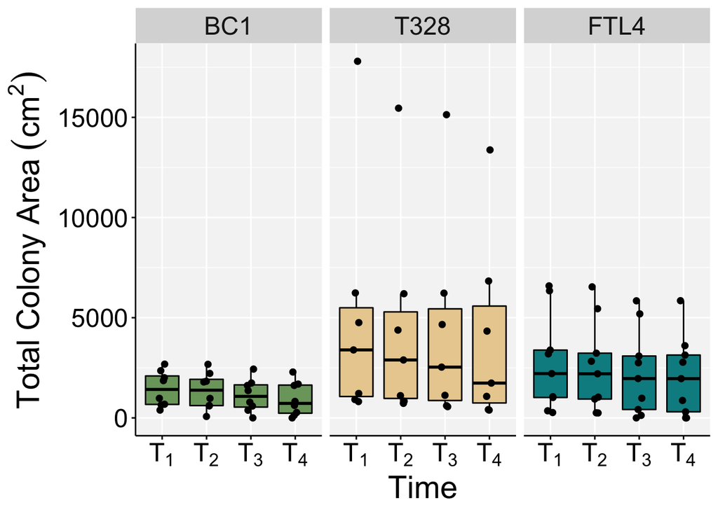

```r
# This forces y axis labels to have 1 decimal place.
scale <- function(x) sprintf("%.0f", x)
# Plotting a boxplot of mean total colony size for each site at each timepoint.
total.colony.box.1 <-
  ggplot(data = corr, aes(x = date, y = total.colony.size))+
  geom_boxplot(aes(fill = site), alpha = 1, outlier.shape = NA, color = "black") +
  geom_point(aes(fill = site), color = "black", size = 1.75, position = position_jitterdodge()) +
  scale_fill_manual(values = c("#7BA46C", "#EACF9E", "#008D91")) +
  scale_x_discrete(labels = c(expression('T'[1]), expression('T'[2]), expression('T'[3]), expression('T'[4])))+
  labs(x = "Time", y = bquote("Total Colony Area" ~ (cm^2)),fill = 'Site') +
  scale_y_continuous(labels = scale)+
  theme(legend.title = element_blank(),
        legend.text = element_text(color = "black", size = 18),
        legend.background = element_blank(),
        legend.position = "bottom")+
  facet_grid(.~site,scales="free")

total.colony.box <- total.colony.box.1 + theme(
  panel.grid.major = element_line(size = 0.5, linetype = 'solid', colour = "white"),
  panel.background = element_rect(fill = '#F5F5F5'),
  plot.title = element_text(hjust = 0.5),
  axis.line = element_line(colour = "black"),
  axis.ticks = element_line(color="black"),
  text = element_text(size = 22, color="black"),
  axis.text.x=element_text(size = 18, color="black"),
  axis.text.y=element_text(size = 18, color="black"),
  legend.position = "none")

total.colony.box
```

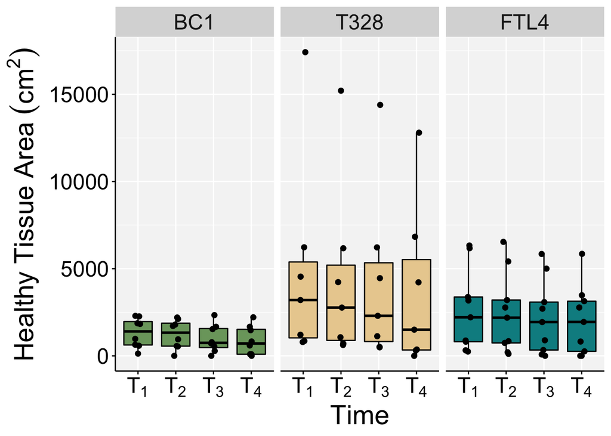

```r
# This forces y axis labels to have 1 decimal place.
scale <- function(x) sprintf("%.0f", x)
# Plotting a boxplot of mean healthy tissue area for each site at each timepoint.
healthy.colony.box.1 <-
  ggplot(data = corr, aes(x = date, y = healthy.area))+
  geom_boxplot(aes(fill = site), alpha = 1, outlier.shape = NA, color = "black") +
  geom_point(aes(fill = site), color = "black", size = 1.75, position = position_jitterdodge()) +
  scale_fill_manual(values = c("#7BA46C", "#EACF9E", "#008D91")) +
  scale_x_discrete(labels = c(expression('T'[1]), expression('T'[2]), expression('T'[3]), expression('T'[4])))+
  labs(x = "Time", y = bquote("Healthy Tissue Area" ~ (cm^2)),fill = 'Site') +
  scale_y_continuous(labels = scale)+
  theme(legend.title = element_blank(),
        legend.text = element_text(color = "black", size = 18),
        legend.background = element_blank(),
        legend.position = "bottom")+
  facet_grid(.~site,scales="free")

healthy.colony.box <- healthy.colony.box.1 + theme(
  panel.grid.major = element_line(size = 0.5, linetype = 'solid', colour = "white"),
  panel.background = element_rect(fill = '#F5F5F5'),
  plot.title = element_text(hjust = 0.5),
  axis.line = element_line(colour = "black"),
  axis.ticks = element_line(color="black"),
  text = element_text(size = 22, color="black"),
  axis.text.x=element_text(size = 18, color="black"),
  axis.text.y=element_text(size = 18, color="black"),
  legend.position = "none")

healthy.colony.box
```

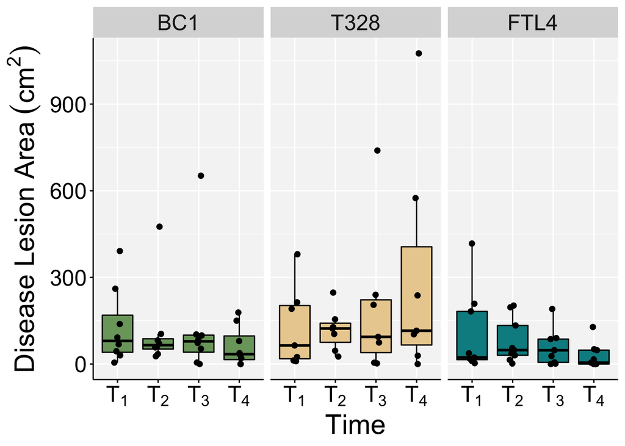

```r
# Plotting box plot of mean disease lesion area for each site at each timepoint.
disease.area.box.1 <-
  ggplot(data = corr, aes(x = date, y = disease.area))+
  geom_boxplot(aes(fill = site), alpha = 1, outlier.shape = NA, color = "black") +
  geom_point(aes(fill = site), color = "black", size = 1.75, position = position_jitterdodge()) +
  scale_fill_manual(values = c("#7BA46C", "#EACF9E", "#008D91")) +
  scale_x_discrete(labels = c(expression('T'[1]), expression('T'[2]), expression('T'[3]), expression('T'[4])))+
  labs(x = "Time", y = bquote('Disease Lesion Area'~(cm^2)), fill = 'Site') +
  scale_y_continuous(labels = scale)+
  theme(legend.title = element_blank(),
        legend.text = element_text(color = "black", size = 18),
        legend.background = element_blank(),
        legend.position = "bottom")+
  facet_grid(.~site,scales="free")

disease.area.box <- disease.area.box.1 + theme(
  panel.grid.major = element_line(size = 0.5, linetype = 'solid', colour = "white"),
  panel.background = element_rect(fill = '#F5F5F5'),
  plot.title = element_text(hjust = 0.5),
  axis.line = element_line(colour = "black"),
  axis.ticks = element_line(color="black"),
  text = element_text(size = 22, color="black"),
  axis.text.x=element_text(size = 18, color="black"),
  axis.text.y=element_text(size = 18, color="black"),
  legend.position = "none")

disease.area.box
```

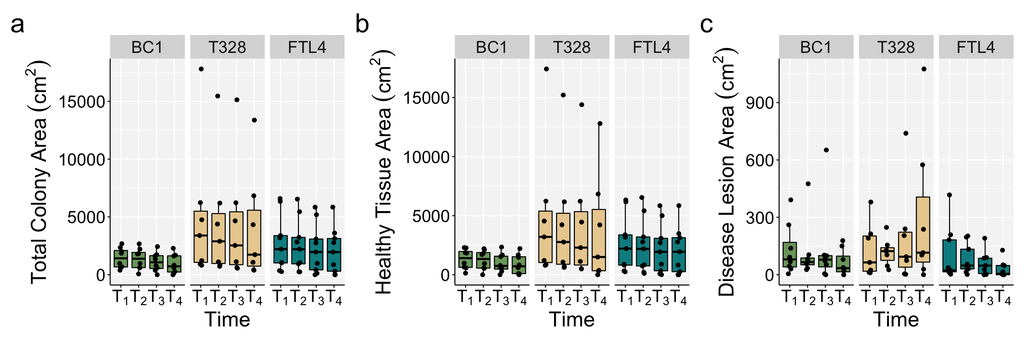

```r
box.plots.patch <- (total.colony.box | healthy.colony.box | disease.area.box) + plot_layout(guides = 'collect') + plot_annotation(tag_levels = 'a') &
  theme(plot.tag = element_text(size = 28))
ggsave("../figures/Fig4.png", plot = box.plots.patch, width = 15, height = 5, units = "in", dpi = 600)
```

# Correlation Plots

Here I will be showing the code for a significant and a non-significant correlation plot as there will be slight difference in the code showing the correlation trend.

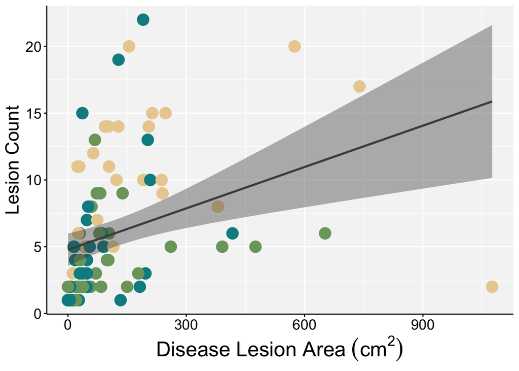

```r
# No correlation
lesion.count.colony.size.1 <-ggplot(corr, aes(x = total.colony.size, y = lesion.count, color = site))+
  geom_point(size = 5)+
  scale_color_manual(values = c("#7BA46C", "#EACF9E", "#008D91"))+
  labs(x = bquote('Total Colony Size'~(cm^2)), y = 'Lesion Count')+
  scale_y_continuous(labels = scale)
lesion.count.colony.size <- lesion.count.colony.size.1 +
  theme(panel.grid.major = element_line(size = 0.5, linetype = 'solid', colour = "white"),
        panel.background = element_rect(fill = '#F5F5F5'),
        plot.title = element_text(hjust = 0.5),
        axis.line = element_line(colour = "black"),
        axis.ticks = element_line(color="black"),
        text = element_text(size=20, color="black"),
        axis.text.x=element_text(size=14, color="black"),
        axis.text.y=element_text(size=14, color="black"),
        axis.title.y = element_text(size = 18, color = 'black'),
        legend.position = "none")

# Significant Correlation
lesion.count.disease.area.1 <-ggplot(corr, aes(x = disease.area, y = lesion.count, color = site))+
  geom_point(size = 5)+
  geom_smooth(method = "lm", fill = 'grey30', color = 'grey30')+
  scale_color_manual(values = c("#7BA46C", "#EACF9E", "#008D91"))+
  labs(x = bquote('Disease Lesion Area'~(cm^2)), y = "Lesion Count") +
  scale_y_continuous(labels = scale)

lesion.count.disease.area <- lesion.count.disease.area.1 +
  theme(panel.grid.major = element_line(size = 0.5, linetype = 'solid', colour = "white"),                 panel.background = element_rect(fill = '#F5F5F5'),
        plot.title = element_text(hjust = 0.5),
        axis.line = element_line(colour = "black"),
        axis.ticks = element_line(color="black"),
        text = element_text(size=20, color="black"),
        axis.text.x=element_text(size=14, color="black"),
        axis.text.y=element_text(size=14, color="black"),
        axis.title.y = element_text(size = 18, color = 'black'))+
        #plot.margin = unit(c(0.5, 1, 0.5, 1.75), "cm"))+
  rremove("legend")
lesion.count.disease.area
```

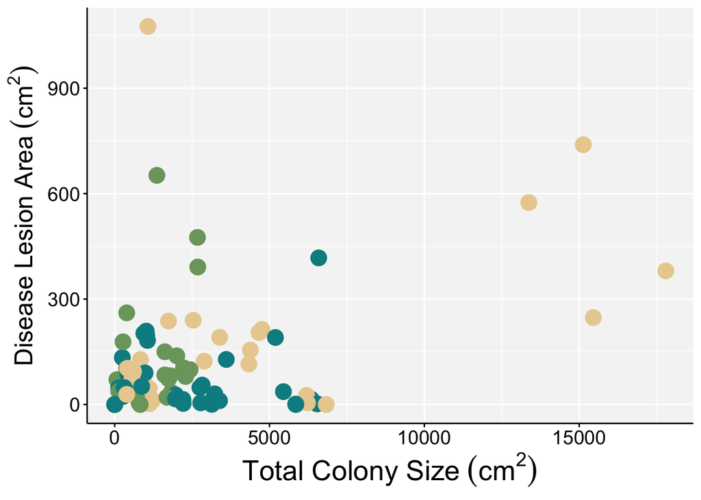

```r
colony.size.disease.area.1 <-ggplot(corr, aes(x = total.colony.size, y = disease.area, color = site))+
  geom_point(size = 5)+
  scale_color_manual(values = c("#7BA46C", "#EACF9E", "#008D91"))+
  labs(x = bquote('Total Colony Size'~(cm^2)), y = bquote('Disease Lesion Area'~(cm^2)), color = "Site") +
  scale_y_continuous(labels = scale)

colony.size.disease.area <- colony.size.disease.area.1 +
  theme(panel.grid.major = element_line(size = 0.5, linetype = 'solid', colour = "white"),
        panel.background = element_rect(fill = '#F5F5F5'),
        plot.title = element_text(hjust = 0.5),
        axis.line = element_line(colour = "black"),
        axis.ticks = element_line(color="black"),
        text = element_text(size=20, color="black"),
        axis.text.x=element_text(size=14, color="black"),
        axis.text.y=element_text(size=14, color="black"),
        axis.title.y = element_text(size = 18, color = 'black'),
        legend.position = "none")
colony.size.disease.area
```

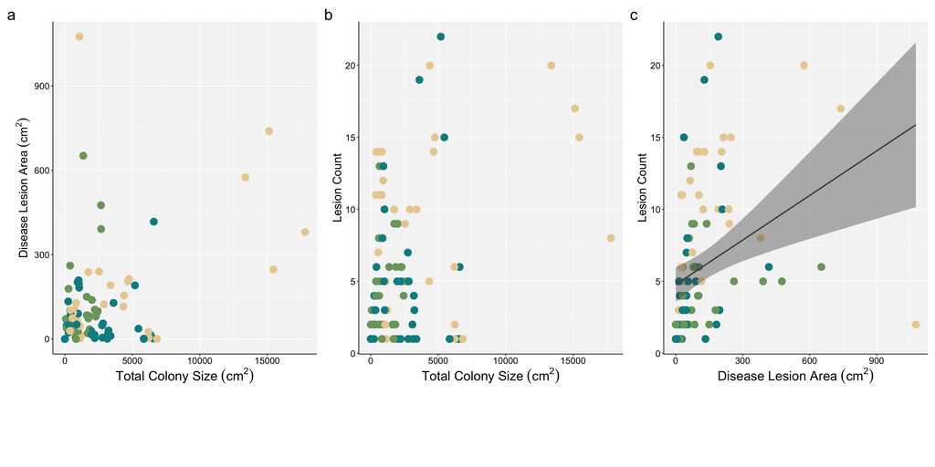

```r
correlation.plots.patch <- (colony.size.disease.area + lesion.count.colony.size + lesion.count.disease.area) / guide_area() + plot_layout(nrow = 2, guides = 'collect', heights = c(5,1)) + plot_annotation(tag_levels = 'a')
ggsave("../figures/FigS3.png", plot = correlation.plots.patch, width = 20, height = 10, units = "in", dpi = 600)
```

# Rates of Loss

Rates of loss were calculated between timepoints, looking at correlations. Kruskal-Wallis Rank Sum Tests were used to determine if rates of loss varied by site, and correlation analyses were used to determine if colony metrics were related to rates of tissue loss.

```r
#subset
corr.loss <- subset(corr, date != "8.24.18")
corr.loss[]<- lapply(corr.loss, function(x) if(is.factor(x)) factor(x) else x)
levels(corr.loss$date)
```

```r
fried.rate <- friedmanTest(y=corr.loss$rate, groups = corr.loss$date, blocks = corr.loss$colony.id)
fried.rate
```

```
##
##  Friedman rank sum test
##
## data:  y, groups and blocks
## Friedman chi-squared = 2.5833, df = 2, p-value = 0.2748
```

```r
fried.loss <- friedmanTest(y=corr.loss$loss, groups = corr.loss$date, blocks = corr.loss$colony.id)
fried.loss
```

```
##
##  Friedman rank sum test
##
## data:  y, groups and blocks
## Friedman chi-squared = 6.25, df = 2, p-value = 0.04394
```

```r
loss.vs.total.colony.size <- cor.test(corr.loss$loss,corr.loss$total.colony.size, method="spearman", use="complete.obs")
loss.vs.total.colony.size
```

```
##
##  Spearman's rank correlation rho
##
## data:  corr.loss$loss and corr.loss$total.colony.size
## S = 65028, p-value = 0.704
## alternative hypothesis: true rho is not equal to 0
## sample estimates:
##         rho
## -0.04554116
```

```r
rate.l1.kw <- kruskal.test(loss ~ site, data = corr.t2)
rate.l1.kw
```

```
##
##  Kruskal-Wallis rank sum test
##
## data:  loss by site
## Kruskal-Wallis chi-squared = 3.0704, df = 2, p-value = 0.2154
```

```r
rate.l2.kw <- kruskal.test(loss ~ site, data=corr.t3)
rate.l2.kw
```

```
##
##  Kruskal-Wallis rank sum test
##
## data:  loss by site
## Kruskal-Wallis chi-squared = 1.9647, df = 2, p-value = 0.3744
```

```r
rate.l3.kw <- kruskal.test(loss ~ site, data=corr.t4)
rate.l3.kw
```

```
##
##  Kruskal-Wallis rank sum test
##
## data:  loss by site
## Kruskal-Wallis chi-squared = 2.6535, df = 2, p-value = 0.2653
```

```r
lossKwTab = data.frame("Data" = "Rate of Tissue Loss", "Test" = "Kruskal-Wallis", "Comparison" = "T1 v T2", "TestStatistic" = rate.l1.kw[["statistic"]][["Kruskal-Wallis chi-squared"]], "p.value" = rate.l1.kw[["p.value"]]) %>%
  add_row(data.frame("Data" = " ", "Test" =  " ", "Comparison" =  "T2 v T3 ", "TestStatistic" = rate.l2.kw[["statistic"]][["Kruskal-Wallis chi-squared"]], "p.value" = rate.l2.kw[["p.value"]])) %>%
add_row(data.frame("Data" = " ", "Test" =  " ", "Comparison" =  "T3 v T4 ", "TestStatistic" = rate.l3.kw[["statistic"]][["Kruskal-Wallis chi-squared"]], "p.value" = rate.l3.kw[["p.value"]])) %>%

mutate_if(is.numeric, round, digits = 3) %>%
mutate(p.value = replace(p.value, p.value >= 0.05, NA)) %>%
mutate(p.value = replace(p.value, p.value < 0.001, "< 0.001")) %>%
mutate_if(is.character, str_replace_all, pattern = "vs", replacement = "–") %>%
flextable() %>%
set_header_labels(Data.set = "Data") %>%
flextable::compose(part = "header", j = "TestStatistic", value = as_paragraph("Test Statistic")) %>%
flextable::compose(part = "header", j = "p.value", value = as_paragraph(as_i("p"), "-value")) %>%
autofit() %>%
font(fontname = "Times New Roman", part = "all") %>%
fontsize(size = 12, part = "all") %>%
bold(part = "header") %>%
colformat_num(j = "TestStatistic", digits = 2) %>%
colformat_num(j = "p.value", digits = 4, na_str = "ns") %>%
align(align = "center", j = "p.value") %>%
align(align = "center", j = "TestStatistic")
lossKwDoc = read_docx()
lossKwDoc = body_add_flextable(lossKwDoc, value = lossKwTab)
print(lossKwDoc, target = "../tables/TableS2.docx")
lossKwTab
```

| Data | Test | Comparison | Test Statistic | p-value |
| --- | --- | --- | --- | --- |
| Rate of Tissue Loss | Kruskal-Wallis | T1 v T2 | 3.07 | ns |
|  |  | T2 v T3 | 1.97 | ns |
|  |  | T3 v T4 | 2.65 | ns |

# Correlation analyses

Correlation analyses were run on rates of loss and various colony metrics.

```r
## Rate of loss 1 and total colony size at T2
spear.t2 <- cor.test(corr.t2$loss,corr.t2$total.colony.size, method="spearman", use="complete.obs")

# Rate of loss 2 and total colony size at T3
spear.t3 <- cor.test(corr.t3$loss,corr.t3$total.colony.size, method="spearman", use="complete.obs")

# Rate of loss 3 and total colony size at T4
spear.t4 <- cor.test(corr.t4$loss,corr.t4$total.colony.size, method="spearman", use="complete.obs")
```

```r
spearLossTab = data.frame("Data" = "Rate of Tissue Loss", "Test" = "Spearman's Rank Correlation", "Comparison" = "T1-T2 ", "rho" = spear.t2[["estimate"]][["rho"]], "p.value" = spear.t2$p.value) %>%
  add_row("Data" = " ", "Test" = " ", "Comparison" = "T2-T3", "rho" = spear.t3[["estimate"]][["rho"]], "p.value" = spear.t3$p.value) %>%
  add_row("Data" = " ", "Test" = " ", "Comparison" = "T3-T4", "rho" = spear.t4[["estimate"]][["rho"]], "p.value" = spear.t4$p.value) %>%

mutate(p.value = replace(p.value, p.value >= 0.05, NA)) %>%
flextable() %>%
set_header_labels(Data.set = "Data") %>%
flextable::compose(part = "header", j = "rho", value = as_paragraph("𝜌")) %>%
flextable::compose(part = "header", j = "p.value", value = as_paragraph(as_i("p"), "-value")) %>%
autofit() %>%
font(fontname = "Times New Roman", part = "all") %>%
fontsize(size = 12, part = "all") %>%
bold(part = "header") %>%
colformat_num(j = "rho", digits = 3) %>%
colformat_num(j = "p.value", digits = 4, na_str = "ns") %>%
align(align = "center", j = "p.value")

spearLossDoc = read_docx()
spearLossDoc = body_add_flextable(spearLossDoc, value = spearLossTab)
print(spearLossDoc, target = "../tables/TableS3.docx")
```

# Visualizing rates of loss

Now using same types plots as before, but for loss data. I am excluding the first time point, and will subset accordingly. And use the same code as above.

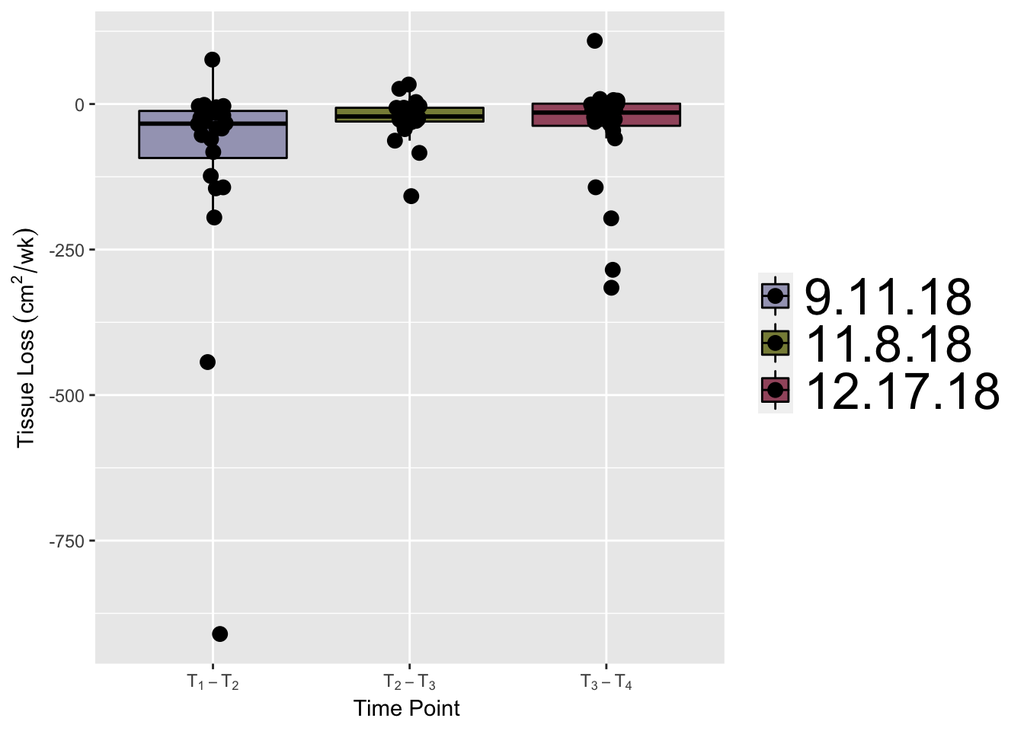

```r
#------------box plot for L1---------------------------
scale <- function(x) sprintf("%.0f", x)
# boxplots comparing shape areas to template
loss.box.1 <- ggplot(data = corr.loss, aes(x = date, y = loss))+
  geom_boxplot(aes(fill = date), alpha = 1, outlier.shape = NA, color = "black") +
  geom_point(aes(fill = date), color = "black", size = 3, position = position_jitterdodge()) +
  scale_fill_manual(values = c("#A4A4BF", "#888C46", "#A3586D")) +
  scale_x_discrete(labels = c(expression('T'[1]-'T'[2]), expression('T'[2]-'T'[3]), expression('T'[3]-'T'[4])))+
  labs(x = "Time Point ", y = bquote('Tissue Loss'~(cm^2/wk)), fill = 'Site') +
  scale_y_continuous(labels = scale)+
  theme(legend.title = element_blank(),
        legend.text = element_text(color = "black", size = 25),
        legend.background = element_blank())
  #facet_grid(.~site,scales="free")
loss.box.1
```

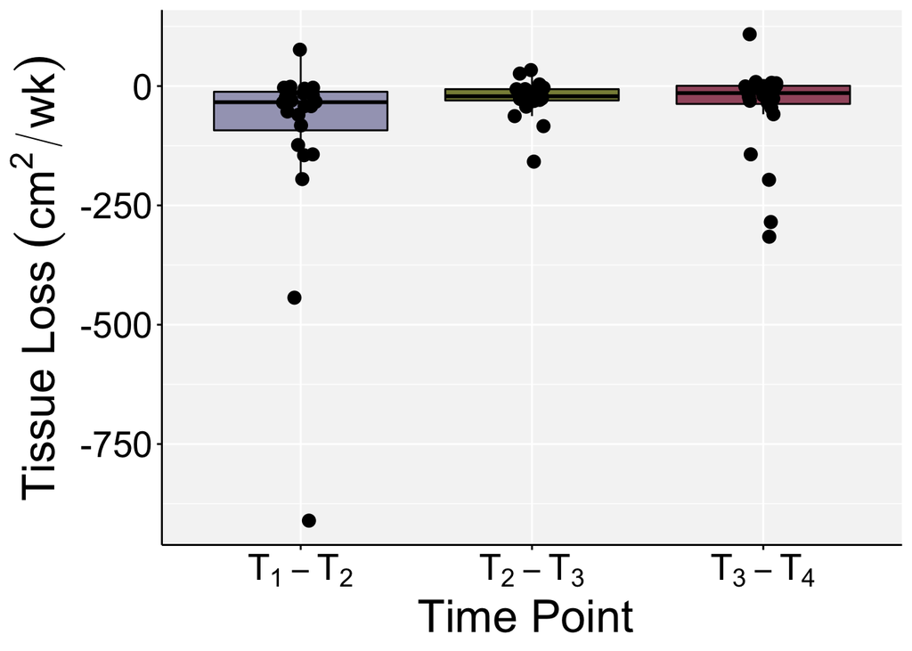

```r
loss.box <- loss.box.1 + theme(
  panel.grid.major = element_line(size = 0.5, linetype = 'solid', colour = "white"),
  panel.background = element_rect(fill = '#F5F5F5'),
  plot.title = element_text(hjust = 0.5),
  axis.line = element_line(colour = "black"),
  axis.ticks = element_line(color="black"),
  text = element_text(size=15, color="black"),
  axis.text.x=element_text(size=20, color="black"),
  axis.text.y=element_text(size=20, color="black"),
  axis.title.y = element_text(size =25, color = 'black'),
  axis.title.x = element_text(size = 25, color = 'black'))+
  rremove('legend')
loss.box
```

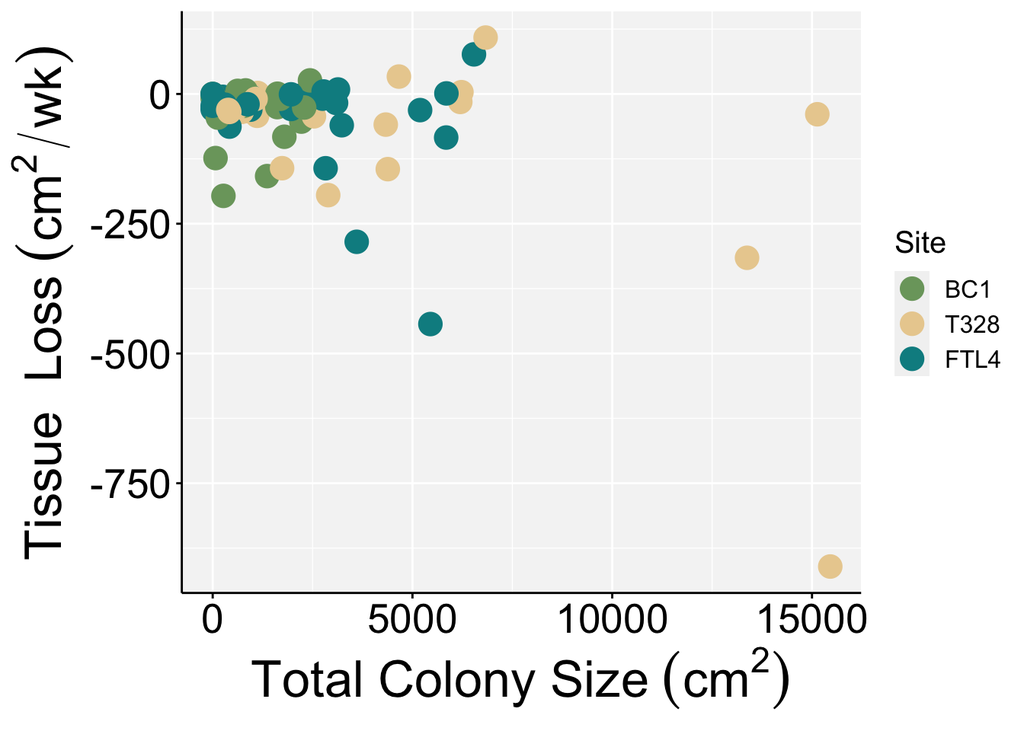

```r
#Correlation plot for colony size and rate of tissue loss

colony.size.loss.1 <-ggplot(corr.loss, aes(x = total.colony.size, y = loss, color = site))+
  geom_point(size = 5)+
  scale_color_manual(values = c("#7BA46C", "#EACF9E", "#008D91"))+
  labs(x = bquote('Total Colony Size'~(cm^2)), y = bquote('Tissue  Loss'~(cm^2/wk)), color = "Site") +
  scale_y_continuous(labels = scale)

colony.size.loss <- colony.size.loss.1 +
  theme(panel.grid.major = element_line(size = 0.5, linetype = 'solid', colour = "white"),
        panel.background = element_rect(fill = '#F5F5F5'),
        plot.title = element_text(hjust = 0.5),
        axis.line = element_line(colour = "black"),
        axis.ticks = element_line(color="black"),
        text = element_text(size=15, color="black"),
  axis.text.x=element_text(size=20, color="black"),
  axis.text.y=element_text(size=20, color="black"),
  axis.title.y = element_text(size =25, color = 'black'),
  axis.title.x = element_text(size = 25, color = 'black'))

colony.size.loss
```

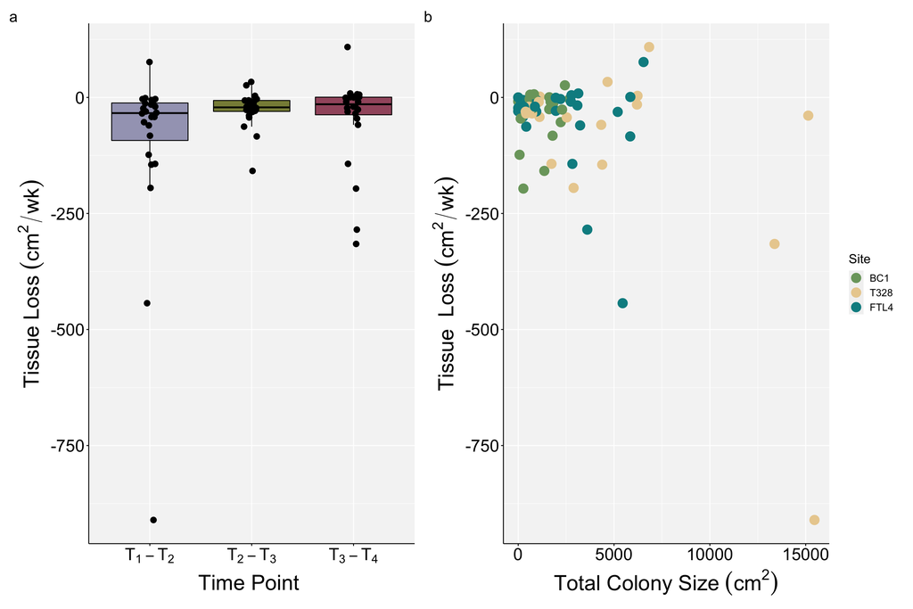

```r
loss.panel <- loss.box + colony.size.loss + guide_area()+ plot_layout(nrow = 1, guides = 'collect', widths = c(5,5,1)) + plot_annotation(tag_levels = 'a')

ggsave("../figures/FigS2.png", plot= loss.panel, width=15, height=10, units="in", dpi=600)
```